# Part II - Ford GoBike System Data Exploration

## by Oumayma Jribi

## Investigation Overview

In this investigation, I wanted to look at the characteristics of those trips that could have a relationship with the trip duration.  
Other than the trip duration which is the feature of interest, the main focus was on: member gender, user type, member birth year, bike-share program enrollment, and starting locations.

## Dataset Overview

The dataset investigated includes information about individual trips made in a bike-sharing system covering the greater San Francisco Bay area.

## Distribution of Trip Durations

Most of trip duration values take on a range from 100 seconds to 2000 seconds.  
When plotted on the log scale, the data points came out normally distributed. There is one peak roughly between 400 and 700 seconds, this shows that most people tend to use bikes for short durations (7 to 12 minutes).

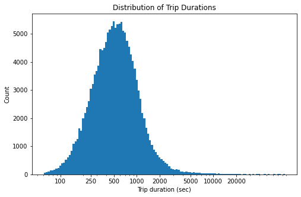

## Relationship between trip duration and member gender:

Members with the gender 'other' are the ones with the longest trip duration with an average duration of approximately 1000 seconds. But since in the univariate section it was shown that 'other' members are a minority, I'll redo this graph keeping only Male and Female.

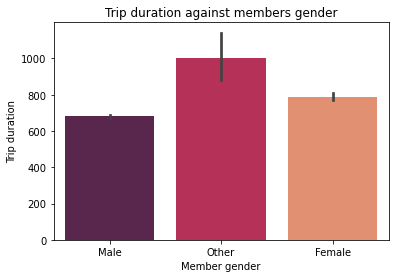

Trip duration is longer for Female members than Males, the difference is not very significant though (around 100 seconds)

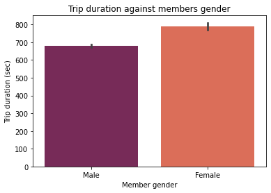

## Relationship between trip duration and user type:

Surprisingly, customer (casual users not enrolled in the system) have longer trip durations than subscribers, with averages of 1456 seconds and 645 seconds respectively.

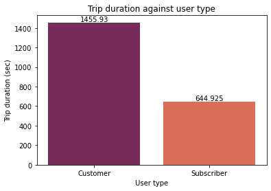

## Relationship between trip duration, gender, and birth year:

Younger females seem to have longer trip durations.  
As for Males, they have slightly higher trip durations than the average for those born between 1988 and 1992, as well as those born on 2000.  
The "Other" gender type, the highest trip durations are for members born on 1989, 1999, followed by the years 1194, 1998, and 1993.

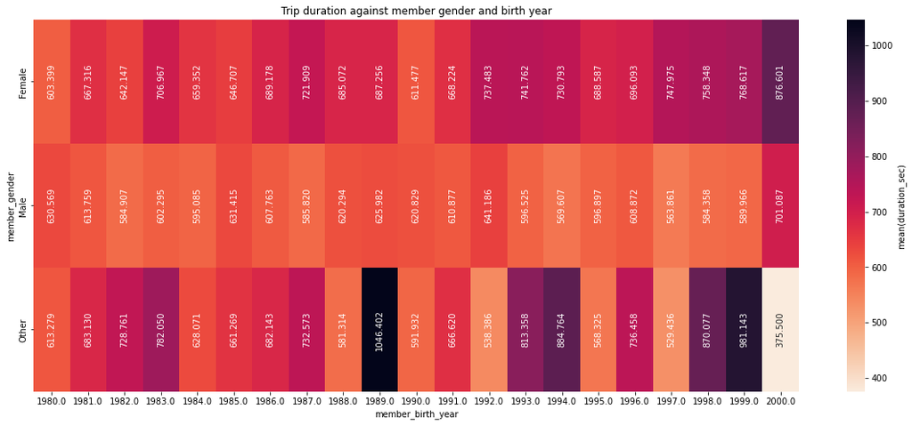

## Relationship between trip duration, bike-share program enrollment and starting stations:

For those enrolled in the bike share program, the highest trip duration corresponds to the starting station of "San Francisco Ferry Building" with a remarkably high average of 2958 seconds, followed by "Steuart St at Market St" and "The Embarcadero at Sansome St".  
This might give a great insight on where most of those enrolled in the bike share program are located and use the system for longer trip durations.

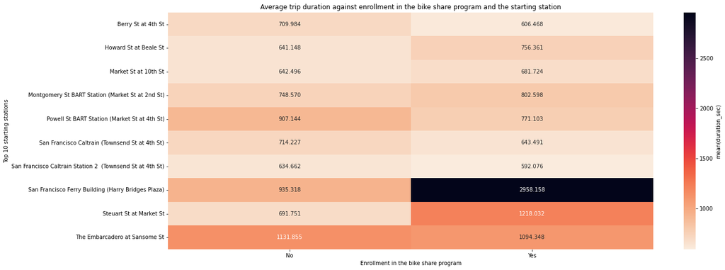